# Practical Machine Learning: Project Report

Alexander Zhou

12/19/2017

## Background

Using devices such as Jawbone Up, Nike FuelBand, and Fitbit it is now possible to collect a large amount of data about personal activity relatively inexpensively. The goal of this project is to use data from accelerometers on the belt, forearm, arm, and dumbell of 6 participants who were asked to perform barbell lifts correctly and incorrectly in 5 different ways, represented as classes in the training set.

## Data Processing

Downloading files as needed and loading them into the workspace

```r
if (!file.exists("pml-training.csv")) {
  download.file(
    "https://d396qusza40orc.cloudfront.net/predmachlearn/pml-training.csv",
    "pml-training.csv")
}
if (!file.exists("pml-testing.csv")) {
  download.file(
    "https://d396qusza40orc.cloudfront.net/predmachlearn/pml-testing.csv",
    "pml-testing.csv")
}

train = read.csv("pml-training.csv", sep = ",", na.strings=c("NA", "#DIV/0!",""))
test = read.csv("pml-testing.csv", sep = ",", na.strings=c("NA", "#DIV/0!",""))

dim(train)
```

```
## [1] 19622   160
```

```r
dim(test)
```

```
## [1]  20 160
```

## Data Cleanup

Remove observation with mission values and reduce data set size by dropping not used variables. Finally slice the training set into a training (70%) and cross validation (30%) part.

```r
naNameRatio.train <- sapply(train, function(x) {sum(is.na(x) == TRUE) / length(x)})
naNameRatio.test <- sapply(test, function(x) {sum(is.na(x) == TRUE) / length(x)})

train <- train[,names(which(naNameRatio.train < 0.95))]
test <- test[,names(which(naNameRatio.test < 0.95))]

train.clean <- train[,!grepl("X|timestamp|user_name|window", names(train))]
test.clean <- test[,!grepl("X|timestamp|user_name|window", names(test))]

index.train <- createDataPartition(train.clean$classe, p=0.70, list = FALSE)
train.data <- train.clean[index.train , ]
train.cross <- train.clean[-index.train , ]
```

## Training Random Forest

```r
control.rf <- trainControl(method = "cv", classProbs = TRUE, savePredictions = TRUE,
                           allowParallel = TRUE, number = 10)
model.rf <- train(classe ~ ., data = train.data, method = "rf", trControl = control.rf)
```

## Model Validation

The model performance is measured against the cross validation data set.

```r
cross.rf <- predict(model.rf, train.cross)
confusionMatrix(train.cross$classe, cross.rf)
```

```
## Confusion Matrix and Statistics
##
##           Reference
## Prediction    A    B    C    D    E
##          A 1671    3    0    0    0
##          B    8 1126    3    2    0
##          C    0    5 1015    6    0
##          D    0    0   15  948    1
##          E    0    1    4    1 1076
##
## Overall Statistics
##
##                Accuracy : 0.9917
##                  95% CI : (0.989, 0.9938)
##     No Information Rate : 0.2853
##     P-Value [Acc > NIR] : < 2.2e-16
##
##                   Kappa : 0.9895
##  Mcnemar's Test P-Value : NA
##
## Statistics by Class:
##
##                      Class: A Class: B Class: C Class: D Class: E
## Sensitivity            0.9952   0.9921   0.9788   0.9906   0.9991
## Specificity            0.9993   0.9973   0.9977   0.9968   0.9988
## Pos Pred Value         0.9982   0.9886   0.9893   0.9834   0.9945
## Neg Pred Value         0.9981   0.9981   0.9955   0.9982   0.9998
## Prevalence             0.2853   0.1929   0.1762   0.1626   0.1830
## Detection Rate         0.2839   0.1913   0.1725   0.1611   0.1828
## Detection Prevalence   0.2845   0.1935   0.1743   0.1638   0.1839
## Balanced Accuracy      0.9973   0.9947   0.9883   0.9937   0.9989
```

```r
postResample(cross.rf, train.cross$classe)
```

```
##  Accuracy     Kappa
## 0.9916737 0.9894673
```

## Model Predictions

The fitted model is now being used to predict the test data, in order to answer the project quiz.

```r
predict(model.rf, newdata = test.clean)
```

```
##  [1] B A B A A E D B A A B C B A E E A B B B
## Levels: A B C D E
```

## Appendix

### 1. Variable Importance Visualization

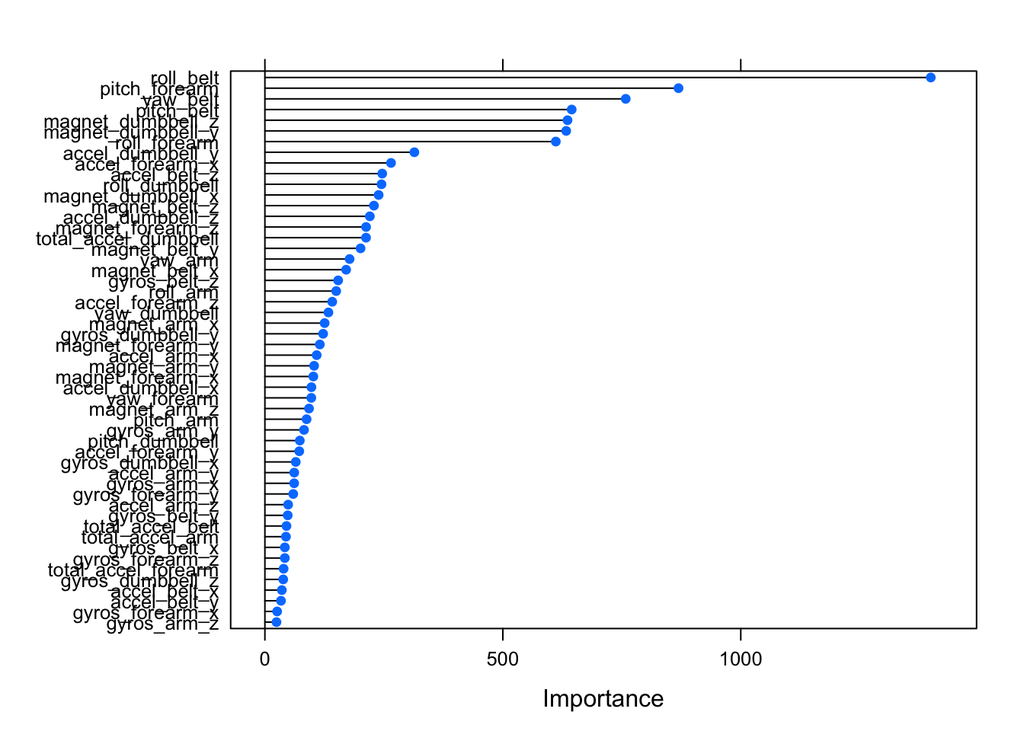

```r
print(plot(varImp(model.rf, scale = FALSE)))
```

### 3. Correlation Matrix Visualization

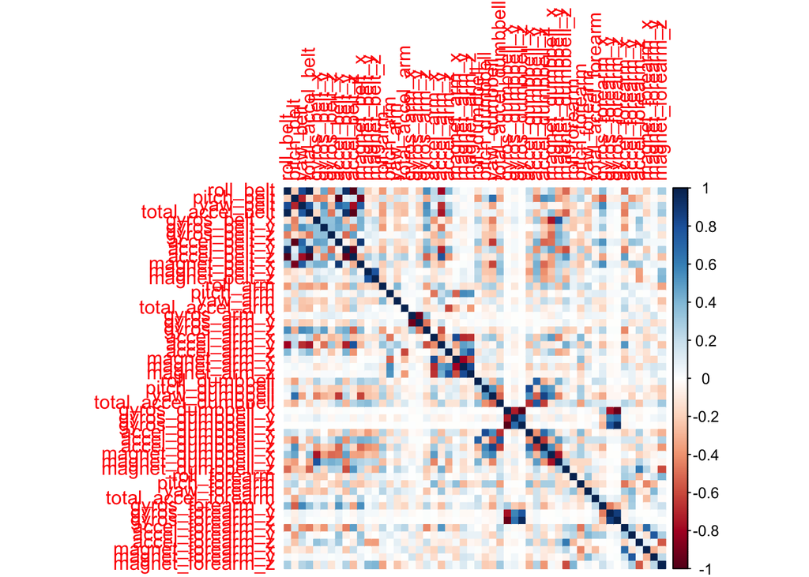

```r
corrplot(cor(train.data[, -length(names(train.data))]), method="color")
```

### 3. Decision Tree Visualization

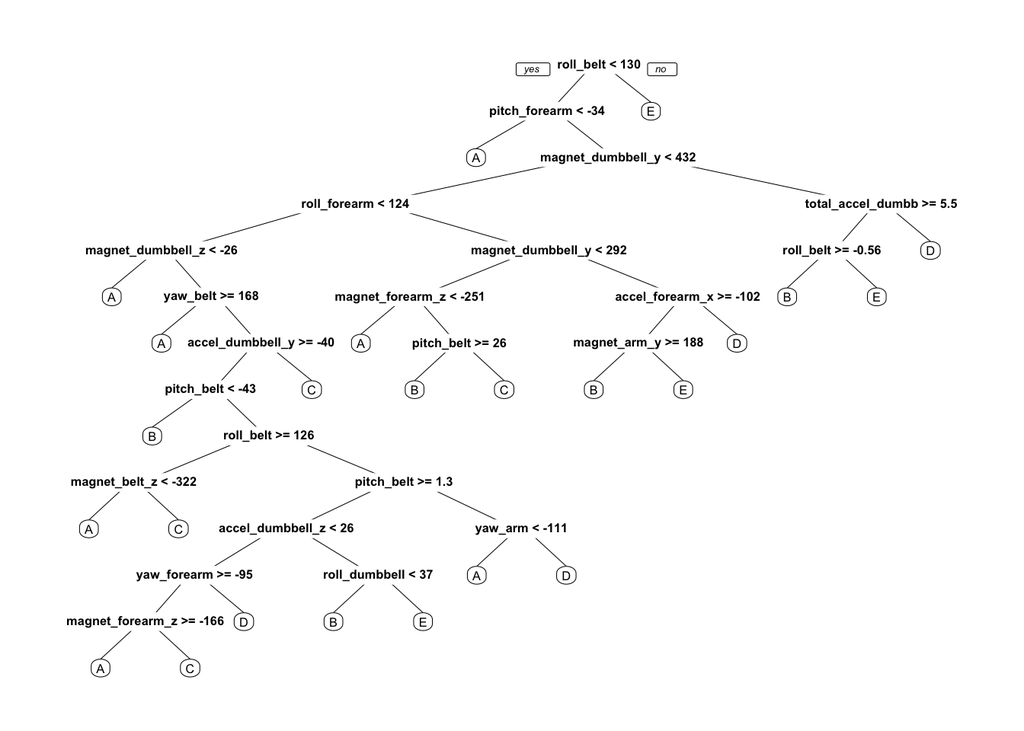

```r
prp(rpart(classe ~ ., data=train.data, method="class"))
```

### 4. Error Rate Visualization

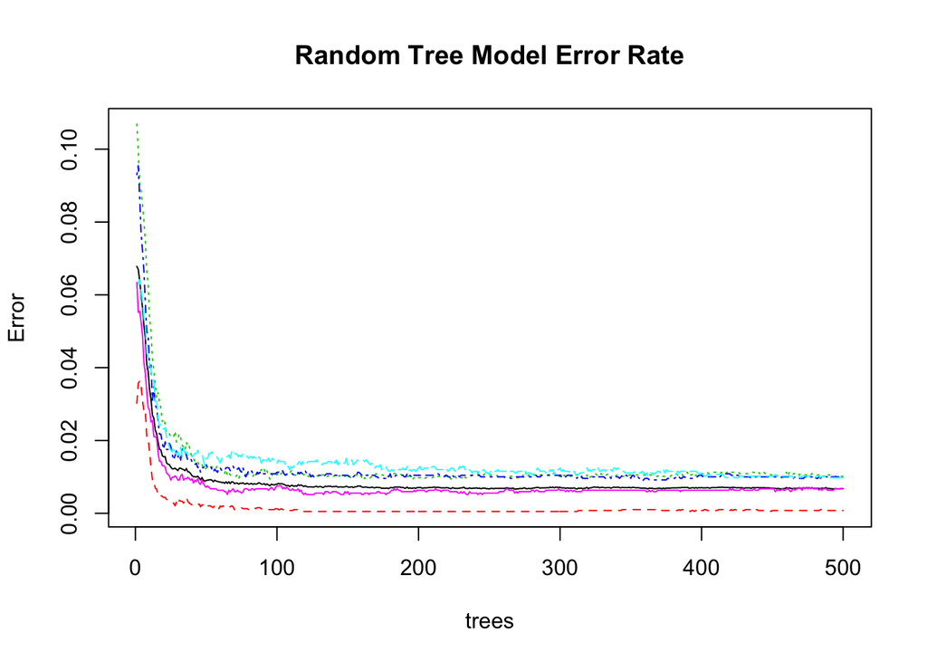

```r
plot(model.rf$finalModel, main = "Random Tree Model Error Rate")
```